# Simple Linear Regression

Part 2

Ranadeep Daw

2024-11-11

## Simple Linear Regression (SLR Model)

1. **Problem Statement**: We have $n$ pair of observations - independent variables/ covariates $\{x_1, x_2 , \ldots, x_n\}$ and dependent variables/ response variables $\{y_1, y_2 , \ldots, y_n\}$.
2. **Model**: We want to model $Y$ as a linear function of $x$ as in:

$$y_i = \beta_0 + x_i \beta_1 +
\epsilon_i$$

## Typical SLR Plot

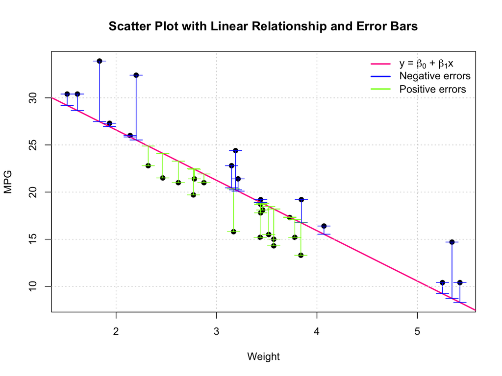

## Example problem

| Income (in 1000) | Food Expenditure(in 100) |
| --- | --- |
| 35 | 5.2 |
| 45 | 6.0 |
| 55 | 7.1 |
| 65 | 7.8 |
| 75 | 8.5 |

## SLR Assumptions

- $\epsilon_i$-s are called the **error terms** or **residuals**.
- **Modeling assumptions**: We make the following assumptions on $\epsilon_i$ :
  - $\mathbb{E}(\epsilon_i) = 0$;
  - var$(\epsilon_i) = \sigma^2$; (Homoscadasticity assumption)

## SLR: Least square method

- How many parameters do we have?
  - $\beta_0$, $\beta_1$, and $\sigma^2$.
- We estimate the parameters using the **least square method**.
- In least square, we do the following:
  - Calculate the sum of squares of errors.
  - Try to minimize it.

## Least square (cont.)

$$\begin{align*}
y_i &= \beta_0 + x_i \beta_1 + \epsilon_i \\
\Rightarrow \epsilon_i &= y_i - \beta_0 - x_i \beta_1 \\
\Rightarrow \epsilon_i^2 &= (y_i - \beta_0 - x_i \beta_1)^2 \\
\Rightarrow \sum_{i=1}^n \epsilon_i^2 &= \sum_{i=1}^n (y_i -
\beta_0 - x_i \beta_1)^2 \\
\end{align*}$$

- **Goal**: Find values of $\beta_0$, $\beta_1$, and $\sigma^2$ that minimizes the last expression. Denote these values as $\widehat{\beta}_0$, $\widehat{\beta}_1$, and $\widehat{\sigma}^2$.

## Normal Equations

- To minimize $\sum_{i=1}^n \epsilon_i^2$, we take derivatives of the expression with respect to $\widehat{\beta}_0$ and $\widehat{\beta}_1$ and equal them to $0$. This leads to the following two equations, known as the normal equations:

$$\begin{align*}
\text{1.} \qquad \Big(\sum_{i=1}^n y_i \Big) &= n \widehat{\beta}_0
+ \Big(\sum_{i=1}^n x_i\Big) \widehat{\beta}_1.\\
\text{2.} \qquad \Big( \sum_{i=1}^n x_i y_i \Big)
&= \Big(\sum_{i=1}^n x_i \Big) \widehat{\beta}_0 +
\Big(\sum_{i=1}^n x_i^2 \Big) \widehat{\beta}_1.\\
\end{align*}$$

- Note: from the data, you can calculate $\sum_{i=1}^n y_i$, $\sum_{i=1}^n x_i$, $\sum_{i=1}^n x_i y_i$, and $\sum_{i=1}^n x_i^2$.

## Solving the normal equation

- Define:
  $$\begin{align*}
  S_{xy} &= \sum_{1=1}^n (x_i - \bar{x}) (y_i - \bar{y}) \\
  &= \sum_{1=1}^n x_i y_i - \frac{\Big(\sum_{1=1}^n x_i \Big)
  \Big(\sum_{1=1}^n y_i \Big)}{n} \\
  S_{xx} &= \sum_{1=1}^n (x_i - \bar{x})^2 \\
  &= \sum_{1=1}^n x_i^2 - \frac{\Big(\sum_{1=1}^n x_i \Big)^2}{n}.
  \end{align*}$$

## Solving (Contd.)

- Then you can solve for $\widehat{\beta}_0$ and $\widehat{\beta}_1$ as below:

$$\begin{align*}
\widehat{\beta}_1 &= \frac{S_{xy}}{S_{xx}}. \\
\widehat{\beta}_0 &= \frac{1}{n} \big( \sum_{i=1}^n y_i \big) -
\frac{1}{n} \big( \sum_{i=1}^n x_i \big)\widehat{\beta}_1 \\
&= \bar{y} - \bar{x} \widehat{\beta}_1.\\
\end{align*}$$

## Fitted SLR

- We estimated the two unknown parameters in the regression line.
- Our estimated sample regression line is:

  $$\begin{align*}
  \widehat{y}_i = \widehat{\beta}_0 + x_i \widehat{\beta}_1
  \end{align*}$$
- $\widehat{y}_i$ is our predicted value from the model.
- $e_i = y_i- \widehat{y}_i$ is the fitted error or residual part that we can not explain.

## Example (Contd.)

| $x_i$ | $y_i$ | $x_i^2$ | $y_i^2$ | $x_i y_i$ |
| --- | --- | --- | --- | --- |
| 35 | 5.2 | 1225 | 27.04 | 182.0 |
| 45 | 6.0 | 2025 | 36.00 | 270.0 |
| 55 | 7.1 | 3025 | 50.41 | 390.5 |
| 65 | 7.8 | 4225 | 60.84 | 507.0 |
| 75 | 8.5 | 5625 | 72.25 | 637.5 |
| 275 | 34.6 | 16125 | 246.54 | 1987.0 |

Note:  
The last row contains the sums for each column.

## Cont.

- Here, $n = 5$.
- $\sum_{i=1}^n x_i^2 = 16125; \sum_{i=1}^n x_i = 275$.
- $S_{xx} = 16125 - 275^2/5 = 1000$.
- $\sum_{i=1}^n x_i y_i = 1987; \sum_{i=1}^n x_i = 275; \sum_{i=1}^n y_i = 34.6$.
- $S_{xy} = 1987 - 275* 34.6/5 = 84$.

## Cont.

- $\widehat{\beta}_1 = \frac{S_{xy}}{S_{xx}} = \frac{84}{1000} = 0.084$.
- $\widehat{\beta}_0 = 34.6/5 - 275/5 * 0.084 = 2.3$.
- Hence, our fitted regression line is:

$$\widehat{y}_i =
2.3 + 0.084 x_i.$$

## Plot

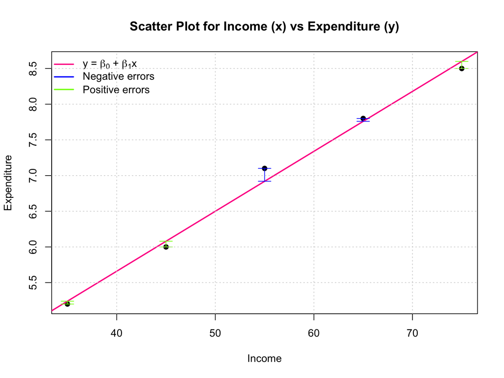

## Interpretation

- $\widehat{\beta}_0$ is the estimated value of the response ($y$) when $x$ is 0.
- $\widehat{\beta}_1$ is the estimated change in the response ($y$) per unit increase in the covariate $x$.
- If $\widehat{\beta}_1 > 0$, $y$ increases with increasing $x$, i.e., positive relationship.
- If $\widehat{\beta}_1 < 0$, $y$ decreases with increasing $x$, i.e., negative relationship.

## Prediction

- Once I have my fitted line, I can first generate a prediction.

$$\begin{align*}
\widehat{y}_1 &= 2.3 + 0.084 * (35) = 5.24 \\
\widehat{y}_2 &= 2.3 + 0.084 * (45) = 6.08 \\
\widehat{y}_3 &= 2.3 + 0.084 * (55) = 6.92 \\
\widehat{y}_4 &= 2.3 + 0.084 * (65) = 7.76 \\
\widehat{y}_5 &= 2.3 + 0.084 * (75) = 8.60 \\
\end{align*}$$

## Errors/ Residuals

- Once I have my predictions, I can now calculate the prediction errors.

$$\begin{align*}
e_1 = y_1 - \widehat{y}_1 &= 5.2 - 5.24 = -0.04\\
e_2 = y_2 - \widehat{y}_2 &= 6.0 - 6.08 = -0.08\\
e_3 = y_3 - \widehat{y}_3 &= 7.1 - 6.92 = 0.18\\
e_4 = y_4 - \widehat{y}_4 &= 7.8 - 7.76 = 0.04\\
e_5 = y_5 - \widehat{y}_5 &= 8.5 - 8.60 = -0.10\\
\end{align*}$$

## Final table

| $x_i$ | $y_i$ | $x_i^2$ | $y_i^2$ | $x_i y_i$ | $\widehat{y}_i$ | $e_i$ |
| --- | --- | --- | --- | --- | --- | --- |
| 35 | 5.2 | 1225 | 27.04 | 182.0 | 5.24 | -0.04 |
| 45 | 6.0 | 2025 | 36.00 | 270.0 | 6.08 | -0.08 |
| 55 | 7.1 | 3025 | 50.41 | 390.5 | 6.92 | 0.18 |
| 65 | 7.8 | 4225 | 60.84 | 507.0 | 7.76 | 0.04 |
| 75 | 8.5 | 5625 | 72.25 | 637.5 | 8.60 | -0.10 |

## True vs Estimated Regression line

|  | **True Regression Line** | **Sample Regression Line** |
| --- | --- | --- |
| **Equation** | $y_i = \beta_0 + \beta_1 x_i + \epsilon$ | $\hat{y}_i = \widehat{\beta}_0 + x_i \widehat{\beta}_1$ |
| **Intercept Coefficient** | $\beta_0$ | $\widehat{\beta}_0$ |
| **Slope Coefficient** | $\beta_1$ | $\widehat{\beta}_1$ |
| **Error term** | $\epsilon_i$ | $e_i = y_i - \widehat{y}_i$ |
| **Error variance** | var$(\epsilon_i) = \sigma^2$ | $\widehat{\sigma}^2$ |

## Error variance estimation

$$\begin{align*}
\widehat{\sigma}^2 &=\frac{1}{n-2} \sum_{i=1}^n e_i^2 \\
&= \frac{1}{n-2} \sum_{i=1}^n \big(y_i - \widehat{y}_i \big)^2 \\
&= \frac{1}{n-2} \sum_{i=1}^n \big(y_i - \widehat{\beta}_0 - x_i
\widehat{\beta}_1 \big)^2 \\
\end{align*}$$

- Error standard devitation: $\widehat{\sigma} = \sqrt{\widehat{\sigma}^2}$.

## Example Continued

- Estimated error variance = $\widehat{\sigma}^2 = \frac{1}{5-2} \big( (-0.04)^2 + (−0.08)^2 + 0.18^2 + 0.04^2$ + $(−0.10)^2 \big) = 0.0173$.
- So, estimated error standard deviation = $\sqrt{0.0173} = 0.1317$.

## $\texttt{R}$ Syntax

- Modeling syntax:

```r
<model_name> = lm(<y_column> ~ <x_column>, data = <data_name>)
```

- Seeing the output:

```r
summary(<model_name>)
```

## Example Continued

- Typical question format will look like this:
  - The following dataframe, named $\texttt{income_data}$ is a dataset of income (in $\$ 1000$) and food expenditure (in $\$ 100$) of 5 families. Using income as the independent variable ($X$) and food expenditure as the dependent variable $(Y)$, build a simple linear regression model.

| Income | Expenditure |
| --- | --- |
| 35 | 5.2 |
| 45 | 6.0 |
| 55 | 7.1 |
| 65 | 7.8 |
| 75 | 8.5 |

## Example (cont.)

```r
income_data = data.frame(
  Income = c(35, 45, 55, 65, 75),
  Expenditure = c(5.2, 6.0, 7.1, 7.8, 8.5)
)
income_data
```

```
##   Income Expenditure
## 1     35         5.2
## 2     45         6.0
## 3     55         7.1
## 4     65         7.8
## 5     75         8.5
```

## Example (cont.)

```r
my_model = lm(Expenditure ~ Income, data = income_data)
summary(my_model)
```

```
##
## Call:
## lm(formula = Expenditure ~ Income, data = income_data)
##
## Residuals:
##     1     2     3     4     5
## -0.04 -0.08  0.18  0.04 -0.10
##
## Coefficients:
##             Estimate Std. Error t value Pr(>|t|)
## (Intercept) 2.300000   0.236432   9.728 0.002307 **
## Income      0.084000   0.004163  20.176 0.000266 ***
## ---
## Signif. codes:  0 '***' 0.001 '**' 0.01 '*' 0.05 '.' 0.1 ' ' 1
##
## Residual standard error: 0.1317 on 3 degrees of freedom
## Multiple R-squared:  0.9927, Adjusted R-squared:  0.9902
## F-statistic: 407.1 on 1 and 3 DF,  p-value: 0.0002662
```

## Summary Output

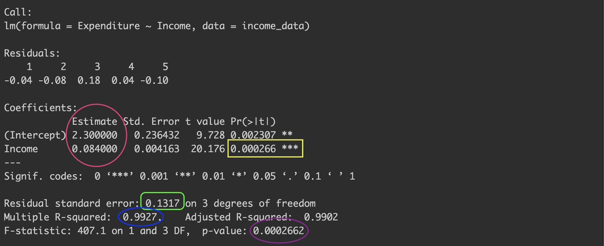

- See the above output [here](https://raw.githubusercontent.com/dawranadeep/24FA_git/refs/heads/main/Practice_qns/img/slr_output2.png).

## Summary of SLR Output: Equation

- **Question:** How can you write the estimated regression model from the output?
  - Look at the Coefficients table’s Estimate column.
  - First one is the intercept ($\widehat{\beta}_0$); second one is the slope ($\widehat{\beta}_1$).
  - So here the estimated regression equation is:

  $\widehat{\text{Expenditure}} = 2.3 + 0.084 *$ Income.

## Summary of SLR Output: Error Standard Deviation

- **Question:** What is the estimated error standard deviation from the output?
  - Look at the Residual Standard Error.
  - $\widehat{\sigma} = 0.1317.$
- **Question:** What is the estimated error variance from the output?
  - You have to square the residual standard error.
  - $\widehat{\sigma}^2 = 0.1317^2 = 0.0173.$

## Link with correlation

- Last class, we discussed correlation:
  $$r
  = \frac{1}{n-1} \sum_{i=1}^n \Big(\frac{x_i -
  \bar{x}}{s_X}\Big) \Big(\frac{y_i - \bar{y}}{s_Y}\Big)$$
- We can link correlation with regression here as below:
  - $\widehat{\beta}_1 = r \sqrt{\frac{S_{yy}}{S_{xx}}}$
  - $S_{yy} = \sum_{1=1}^n (y_i - \bar{y})^2 = \sum_{1=1}^n y_i^2 - \frac{\Big(\sum_{1=1}^n y_i \Big)^2}{n}$.

## $R$-square ($R^2$)

- To evaluate the strength of the regression model, we define the $R$-square.
- In SLR, this is the square of the correlation coefficient $r$.
- Since $-1 \leq r \leq +1$, $0 \leq R^2 \leq 1$.
- A high $R^2$ value indicates a strong linear relationship between $x$ and $y$.

## A property regarding $R^2$

- You can show that:
  $$\begin{align*}
  \sum_{i=1}^n \big(y_i - \bar{y} \big)^2 &= \sum_{i=1}^n
  \big(\widehat{y}_i - \bar{y} \big)^2 + \sum_{i=1}^n \big(y_i -
  \widehat{y}_i \big)^2
  \end{align*}$$
- The first term is $S_{yy}$ or total variability in the response. It is denoted as SST (total sum of squares).
- The second term is **regression sum of squares**, denoted as SS$_{\text{reg}}$.
- The last term is **error sum of squares**, denoted as SSE.
- SST = SS$_{\text{reg}}$ + SSE.

## $R$-square: Properties and Interpretation

- $R^2 = \widehat{\beta}_1^2 \frac{S_{xx}}{S_{yy}}$.
- $R^2 = 1 - \frac{S_{ee}}{S_{yy}}$, where S$_{ee}$ is the total residual sum of squares = $\sum_{1=1}^n (e_i - \bar{e})^2 = \sum_{1=1}^n e_i^2$.
- $R^2 = \frac{S_{\text{reg}}}{S_{yy}}$, where $S_{\text{reg}} = S_{yy} - S_{ee}$.
- $R^2$ is the fraction of variability explained of $y$ divided by the total variability in $y$. So, in other words, $R^2$ is the percentage of explained variability of $y$ by the model.

## Summary of SLR Output: $R^2$

- **Question:** What is the $R^2$ of the regression model from the output?
  - Look at the Multiple R-squared option in the output.
  - $R^2 = 0.9927$.

## Does the model make sense?

- We can always fit a linear model like this.
- But sometimes there is just no relationship between x and y.
- Hence, it is our goal to check if the model is sensible or not.
- There are two ways to check it – you will understand the differences better in the multiple linear regression lecture.

## Hypothesis Test 1: Test for the model performance

- First, if there is no relationship, the slope coefficient should have a value close to $0$.
- Hence, we want to test the null hypothesis $H_0:$ The model has no explanatory power, $\beta_1 = 0$ (the slope is zero).
- Alternate hypothesis is $H_A: \beta_1 \neq 0$, i.e., the slope is not zero.
- **Careful, we are not testing with $\widehat{\beta}_1$.**
- For this, we need an additional assumption that: $\epsilon_i \sim \mathbb{N}(0, \sigma^2)$

## SLR Output: Model Performance

- **Question:** From the output, is the regression model explaining anything at $\alpha = 0.05$?
  - Look at the very last $p$-value in the output.
  - Since $p$-value (0.00026) < $\alpha$ (0.05), we reject $H_0$ that the model is meaningless.
  - So, here my model is explaining something about $y$ from $x$.

## Hypothesis Test 2: Test for Individual Coefficients

- Another test for $H_0$: $\beta_1 = 0$ vs $H_A$: $\beta_1 \neq 0$.
- This time, we will perform a one sample $t$ test.
- Same hypothesis as before, but this is a different test.
- You will see the differences between the $t$ and the $F$ test more in the multiple linear regression case.

## SLR Output: Test for $\beta_1 = 0$

- From the $\texttt{R}$ output, look the Coefficients table, last column named *Pr(>|t|)* . Look for the row corresponding to $\widehat{\beta}_1$.
- This is the $p$ value. Reject $H_0$ if $p$ value < $\alpha$.
- Also note, in the coefficients table, column $1$ (named *Estimate*) is the $\widehat{\beta}_1$.
- Column $2$ is the sd of $\widehat{\beta}_1$.
- The column $3$ (named *t value*) is the $t$ statistic.

## SLR Output: Test for $\beta_1 = 0$ (cont.)

- **Question:** From the output, can you test if $\beta_1 = 0$ at $\alpha = 0.05$?
  - Look at the column *Pr(>|t|)* in the coefficients table; row 2 (or the row for $\beta_1$.
  - Since $p$-value (0.00026) < $\alpha$ (0.05), we reject $H_0$ that $\beta_1 = 0$.
  - Also note that here the $t$ statistic is: **20.176** (column 3).

## Leverage Score

- **Leverage score** quantifies how much influence an individual data point has on the predicted values.
- It has the following formula:
  $$h_i = \frac{1}{n} + \frac{(x_i - \bar{x})^2}{\sum_{j=1}^n (x_j -
  \bar{x})^2}$$

## Leverage Score (cont.)

- Points with **higher leverage** are further from the mean of the predictor variable $X$, i.e., more extreme observation in $X$.
- Points with **higher leverage** cause large changes in the parameter estimates ($\widehat{\beta}_0$, $\widehat{\beta}_1$,$\widehat{\sigma}^2$) when they are deleted.

## $\texttt{R}$ Syntax

```r
plot(hatvalues(<model_name>), type = 'h')
```

- Example:

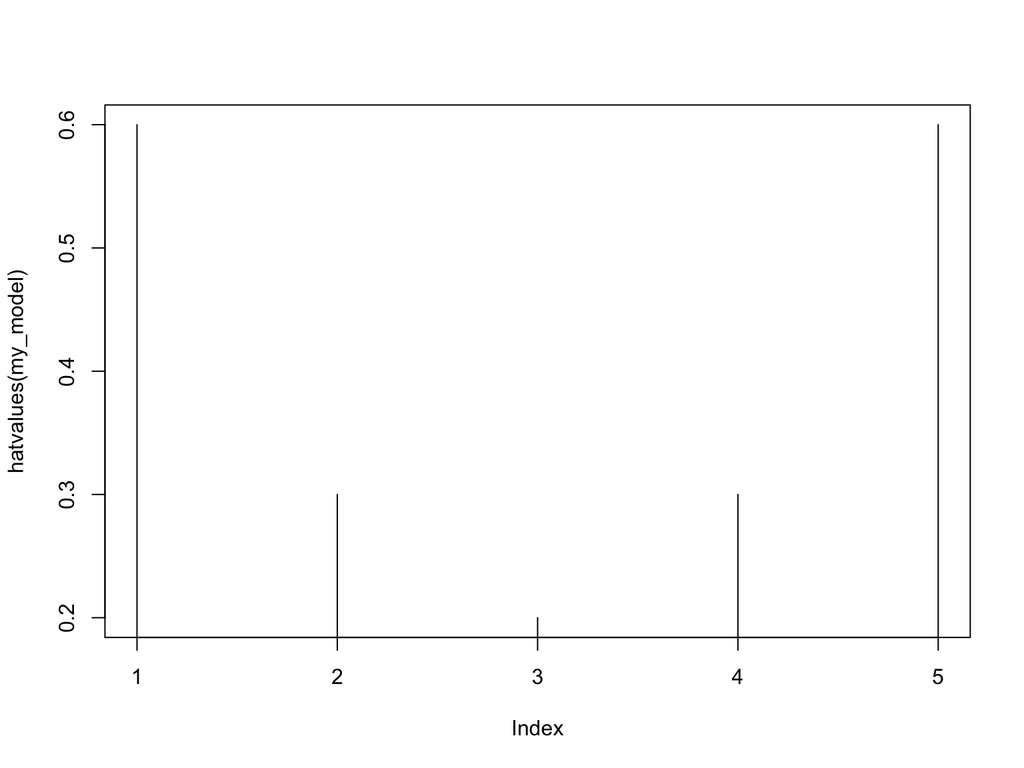

```r
plot(hatvalues(my_model), type = 'h')
```

## Interpreting Leverage Score

- Leverage scores range between 0 and 1, i.e., $0 \leq h_i \leq 1$.
- A **high leverage** point is usually defined as one where:
  $$h_i > \frac{2}{n}$$
- You may see other thresholds too. In practical examples, you have to experiment with different values to check what’s working.
- High leverage points may not necessarily be outliers, but they can significantly affect the regression model’s fit.

## Cook’s Distance

- **Cook’s Distance** is a measure used to assess the influence of an observation on the regression model.
- **Cook’s Distance** quantifies how much the regression coefficients would change if a particular observation was removed from the model.
- It combines both the **residual** (how far the actual point is from the predicted value) and the **leverage** (how far the point is from the mean of the predictor).

## Formula for Cook’s Distance

- $e_i$ is the **residual** for the $i$-th observation.
- $h_i$ is the **leverage score** for the $i$-th observation.

## Interpreting Cook’s Distance

- You will see various thresholds for **high influence** such as:
  - $D_i > 1$
  - $D_i > 3 \bar{D}$
- In real data, you have to keep experimenting which one works best for you.

## $\texttt{R}$ Syntax

```r
plot(cooks.distance(<model_name>), type = 'h')
```

- Example:

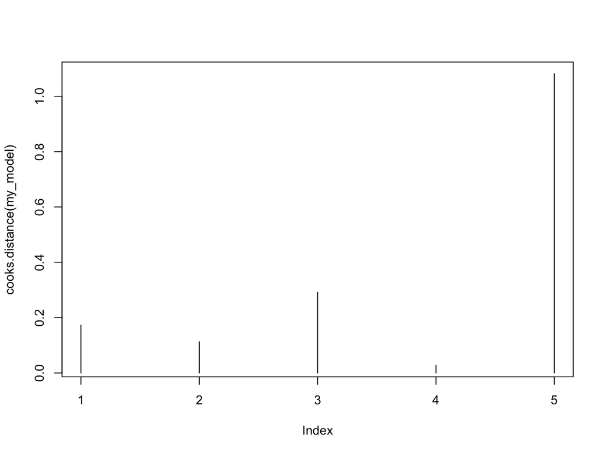

```r
plot(cooks.distance(my_model), type = 'h')
```